# DATA608_Story3

John Ferrara

2025-10-25

## Story 3 Assignment

#### Instructions

The CDC publishes firearm mortality for each State per 100,000 persons https://www.cdc.gov/nchs/pressroom/sosmap/firearm_mortality/firearm.htm. Each State’ firearm control laws can be categorized as very strict to very lax. The purpose of this Story is to answer the question, ” Do stricter firearm control laws help reduce firearm mortality?”

For this assignment you will need to: - Access the firearm mortality data from the CDC using an available API (https://open.cdc.gov/apis.html) - Create a 5 point Likert scale categorizing gun control laws from most lax to strictest and assign each state to the most appropriate Likert bin. - Determine wether stricter gun control laws result in reduced gun violence deaths - Present your story using heat maps

Notes: - You may not use the same desktop application that you have used for a previous story. - If you use color in your visuals you must use an accessible color palette. - This assignment is due at the end of the week six of the semester

## Beginning of Work

##### NOTE: The CDC Apis do not seem to be functional, I dont know if it is a result of the government shut down or the Trump administration’s data scrubbing efforts. I will be doing my best to source and leverage data from whateversources I can find on this topic.

### Reading in data

```r
## Pulling in the manually downloaded FireArm Death Data because of the WONDER API being down. (https://www.cdc.gov/nchs/state-stats/deaths/firearms.html#cdc_data_surveillance_section_1-mortality-rates)
# cdc_deaths_file <- "C:/Users/johnf/Documents/Github/CUNY_SPS_WORK/FALL2025/DATA608/Story3/cdc_gundeaths_state.csv"
cdc_deaths_file <-"https://raw.githubusercontent.com/jhnboyy/CUNY_SPS_WORK/refs/heads/main/FALL2025/DATA608/Story3/cdc_gundeaths_state.csv"
deaths    <- read_csv(cdc_deaths_file)

# head(deaths)

## Everytown Gun Law Ranking Data (https://everytownresearch.org/rankings/) 2025
# everytown_gun_data <- "C:/Users/johnf/Documents/Github/CUNY_SPS_WORK/FALL2025/DATA608/Story3/everytown_gun_law_rankings_by_category.csv"
everytown_gun_data <-"https://raw.githubusercontent.com/jhnboyy/CUNY_SPS_WORK/refs/heads/main/FALL2025/DATA608/Story3/everytown_gun_law_rankings_by_category.csv"
everytown <- read_csv(everytown_gun_data)

# head(everytown)

## Giffords Law Center (https://giffords.org/lawcenter/resources/scorecard/) 2025, its their latest scorecard?
# gifford_gun_data <- "C:/Users/johnf/Documents/Github/CUNY_SPS_WORK/FALL2025/DATA608/Story3/giffords_gun_laws_and_death_rates.csv"
gifford_gun_data <-"https://raw.githubusercontent.com/jhnboyy/CUNY_SPS_WORK/refs/heads/main/FALL2025/DATA608/Story3/giffords_gun_laws_and_death_rates.csv"
giffords  <- read_csv(gifford_gun_data)

#head(giffords)

## Shapefile for Mapping
states_sf <- tigris::states(cb = TRUE, year = 2023, class = "sf") |> select(STUSPS, NAME, GEOID, geometry) |>
   filter(!NAME %in% c("Puerto Rico", "Guam", "American Samoa",
                       "Commonwealth of the Northern Mariana Islands",
                       "United States Virgin Islands")) |>
  # Additional projection shifts for aesthetics
  tigris::shift_geometry() |>  st_transform(5070)
```

[output not shown]

```r
# print(unique(states_sf$NAME)) ## 51 values because of DC

## Testing Map Plot
# ggplot(states_sf) +  geom_sf() +
#   theme_minimal()
```

### Processing Data to Work with Visuals

```r
## Limiting the CDC Death data to latest year.
## Latest year is 2023, which is not 2025. However, with the status of the CDC website and API, I dont believe there is additional data for 2025. However, after spot checking against the giffords data, this may be the data they used as well.

deaths_latest <- subset(deaths,YEAR == 2023)

## Joining everytown and giffords. Giffords data has no year, however it's their latest annual ranking, so its safe to assume its 2025.

## limiting and renaming
everytown <- everytown %>%
  rename(EverytownLawStrengthRank = `Gun Law Strength Rank`) %>%
  select(-Category)

# head(everytown)

## Only interested in the gun law strength rank
giffords <- giffords %>%
  select(State, `Gun Law Strength Rank`) %>%
  rename(GiffordsLawStrengthRank = `Gun Law Strength Rank`)

# head(giffords)

## Joining them, and adding another column for both rank scores for a custom score. Points out of 100
gun_law_strgth <- giffords %>%  left_join(everytown, by = "State") |> mutate(AverageRank = (GiffordsLawStrengthRank + EverytownLawStrengthRank) / 2)

# print(unique(gun_law_strgth$AverageRank))

## making this scale simple, 50 states so brackets of 10
gun_law_strgth <- gun_law_strgth %>%  mutate(StrengthScale =  case_when(AverageRank <= 10 ~ "Very Strong", AverageRank <= 20 ~ "Strong",
                                                                        AverageRank <= 30 ~ "Moderate", AverageRank <= 40 ~ "Weak", TRUE ~ "Very Weak"))
```

```r
### Joining both of these into the shapefile map for plotting.

map_sf <- states_sf |>
  left_join(gun_law_strgth, by = c("NAME" = "State")) |>
  left_join(deaths_latest, by =c("STUSPS" = "STATE"))

## Creating another custom index for heat map

## ordering them
levels_strength <- c("Very Strong","Strong","Moderate","Weak","Very Weak")
levels_score <- c("Best (Top 20%)","Good (Upper-Middle 20%)","Neutral (Middle 20%)","Bad (Lower-Middle 20%)", "Worst (Bottom 20%)")

map_sf <- map_sf %>%  mutate(GunScoreIndex = (AverageRank+RATE)/100) |>
  mutate( GunScoreCategory = ntile(GunScoreIndex, 5),
            GunScoreCategory = case_when(
      GunScoreCategory == 1 ~ "Best (Top 20%)",
      GunScoreCategory == 2 ~ "Good (Upper-Middle 20%)",
      GunScoreCategory == 3 ~ "Neutral (Middle 20%)" ,
      GunScoreCategory == 4 ~ "Bad (Lower-Middle 20%)",
      GunScoreCategory == 5 ~ "Worst (Bottom 20%)",
      TRUE ~ NA_character_)) |>
    mutate( StrengthScale = factor(StrengthScale, levels = levels_strength, ordered = TRUE)) |>
    mutate( GunScoreCategory = factor(GunScoreCategory, levels = levels_score, ordered = TRUE))

## check Breakdown of the scoring
# map_sf
```

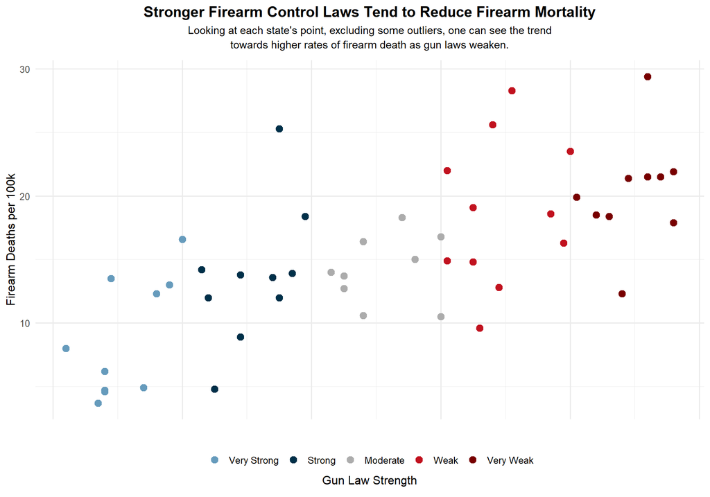

```r
sub_txt <- str_wrap(
  "Looking at each state's point, excluding some outliers, one can see the trend towards higher rates of firearm death as gun laws weaken.",
  width = 80
)

ggplot(st_drop_geometry(map_sf), aes(x = AverageRank, y = RATE)) +
  geom_point(aes(color = StrengthScale), size = 3)+
  scale_x_continuous(name ='')+
  scale_y_continuous(name = "Firearm Deaths per 100k") +
  scale_color_manual(values = c("Very Weak" = "#780000",
                                "Weak" = "#C1121F",
                                "Moderate" = "#ACACAC",
                                "Strong" = "#003049",
                                "Very Strong" = "#669BBC"
                                ),
                         name = "Gun Law Strength",
                         na.translate = FALSE ,
                         guide = guide_legend(
                         title.position = "bottom",
                         title.hjust = 0.5
                         )

  ) +
  labs(
    title = "Stronger Firearm Control Laws Tend to Reduce Firearm Mortality",
    subtitle = sub_txt
  ) +
  theme_minimal(base_size = 12) +
  theme(
    legend.position = "bottom",
    plot.title = element_text(face = "bold", size = 15,hjust=0.5),
    plot.subtitle = element_text(size = 11, lineheight = 1.1,hjust=0.5, margin = margin(b = 10)),
    axis.text.x = element_blank(),
    axis.ticks.x = element_blank()
  )
```

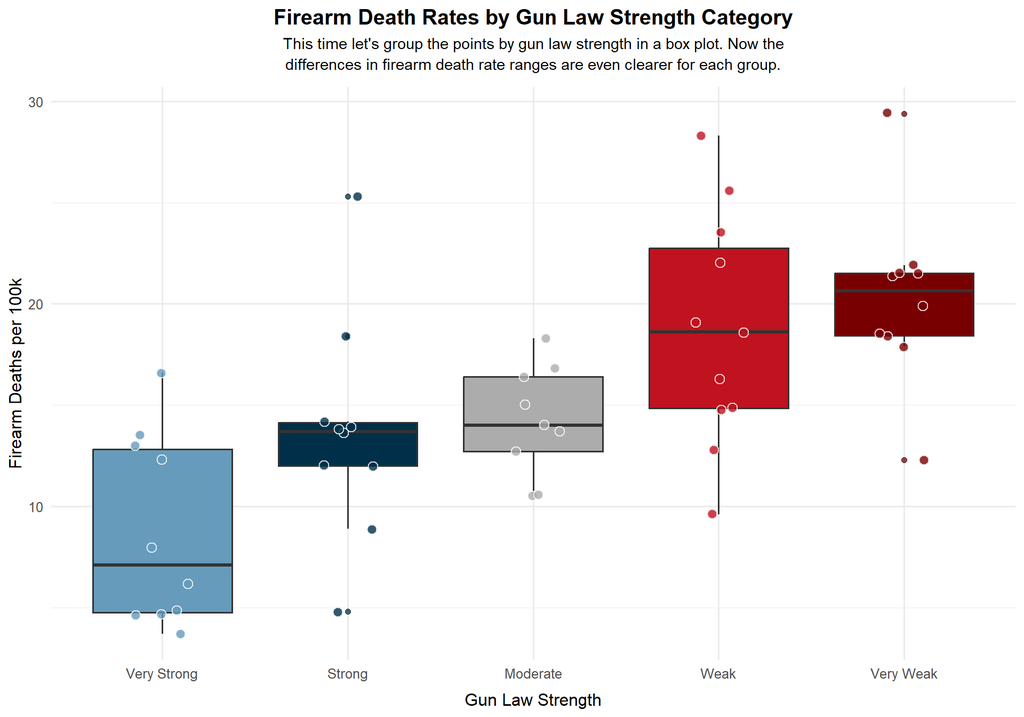

```r
sub_txt2 <- str_wrap(
  "This time let's group the points by gun law strength in a box plot. Now the differences in firearm death rate ranges are even clearer for each group.",
  width = 80
)

# Confirming no Na, DC is a problem here so just removing for box.
map_sf_box <-  map_sf %>%   filter(!is.na(StrengthScale))

## Box plot
ggplot(map_sf_box, aes(x = StrengthScale, y = RATE, fill = StrengthScale)) +
  geom_boxplot(width = 0.75, outlier.shape = 21, outlier.alpha = 0.75) +
  geom_jitter(aes(fill = StrengthScale),color = "white",  width = 0.15,  alpha = 0.8,  size = 3, shape = 21) +
  scale_fill_manual(values = c( "Very Weak"   = "#780000","Weak"        = "#C1121F","Moderate"    = "#ACACAC",
                                "Strong"      = "#003049","Very Strong" = "#669BBC"),  guide = "none",na.translate = FALSE ,) +
  labs(x = "Gun Law Strength",y = "Firearm Deaths per 100k", title = "Firearm Death Rates by Gun Law Strength Category", subtitle = sub_txt2) +
  theme_minimal(base_size = 12) +
  theme(axis.title.x = element_text(margin = margin(t = 8)),
        plot.title = element_text(face = "bold", size = 15,hjust=0.5),
        plot.subtitle = element_text(size = 11, lineheight = 1.1,hjust=0.5, margin = margin(b = 10)),)
```

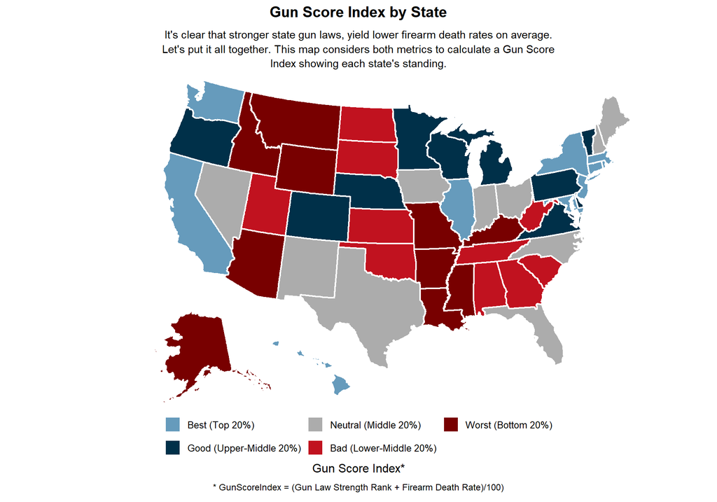

```r
sub_txt3 = str_wrap(
  "It's clear that stronger state gun laws, yield lower firearm death rates on average. Let's put it all together. This map considers both metrics to calculate a Gun Score Index showing each state's standing.",
  width = 85
)

ggplot(map_sf) +
  geom_sf(aes(fill = GunScoreCategory), color = "white", linewidth = 0.75, hjust =0.5) +
  coord_sf(expand = FALSE)+
  scale_fill_manual(
    values = c(  "Best (Top 20%)"    = "#669BBC",  "Good (Upper-Middle 20%)"   = "#003049",  "Neutral (Middle 20%)" = "#ACACAC" ,"Bad (Lower-Middle 20%)" = "#C1121F", "Worst (Bottom 20%)" = "#780000" ),na.translate = FALSE, name = "Gun Score Index*",
   guide = guide_legend(title.position = "bottom",   title.hjust = 0.5, nrow = 2,)
  ) +
  labs(
    title = "Gun Score Index by State",
    subtitle = sub_txt3,
    caption = "* GunScoreIndex = (Gun Law Strength Rank + Firearm Death Rate)/100)"
  ) +
  theme_void(base_size = 12) +
  theme(
    legend.position = "bottom",
    axis.title.x = element_text(margin = margin(t = 8)),
    plot.title = element_text(face = "bold", size = 15,hjust=0.5),
    plot.subtitle = element_text(size = 11, lineheight = 1.1, hjust=0.5, margin = margin(t=10,b = 10)),
    plot.caption = element_text(size = 9, , hjust=0.5, margin = margin(t=10, b = 10)),)
```

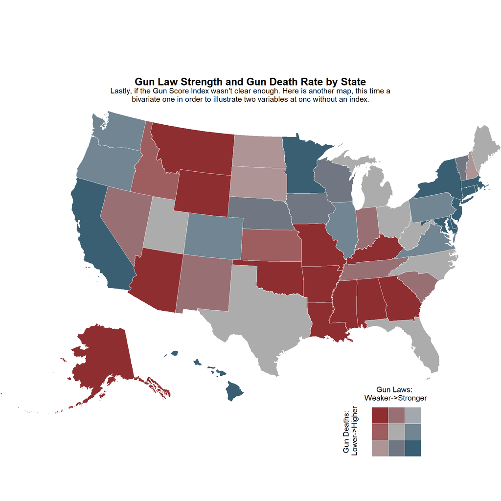

```r
sub_txt4 = str_wrap(
  "Lastly, if the Gun Score Index wasn't clear enough. Here is another map, this time a bivariate one in order to illustrate two variables at onc without an index.",
  width = 85
)

map_sf2 <- map_sf|>mutate(LawStrengthScore = 51 - AverageRank)

# Classify both variables into terciles (3x3)
map_sf_bi <- bi_class(
  map_sf2,
  x = LawStrengthScore ,
  y = RATE,
  style = "quantile",
  dim = 3
)
### used AI to help with pallette building
# 2) Custom 3×3 palette
blend <- function(col1, col2, w = 0.5) {
  c1 <- col2rgb(col1); c2 <- col2rgb(col2)
  grDevices::rgb((1-w)*c1[1,]+w*c2[1,], (1-w)*c1[2,]+w*c2[2,], (1-w)*c1[3,]+w*c2[3,], maxColorValue = 255)
}
# easing (use /2 because dim=3 → indices 0..2)
ease <- function(t, p = 0.9) t^p

blue_dark <- "#003049"  # best corner (strong + low)
blue_light <- "#669BBC"
red_dark  <- "#780000"  # worst corner (weak + high)
red_light <- "#C1121F"
neutral   <- "#ACACAC"

# Build 3×3 grid (x: weak→strong = 1..3, y: low→high = 1..3)
mat_cols <- list()
for (y in 1:3) {
  y_t <- ease((y-1)/2)  # 0..1, more red as deaths increase
  anchor_red  <- blend(neutral, red_dark,  0.70 * y_t)
  anchor_blue <- blend(neutral, blue_dark, 0.70 * (1 - y_t))
  # soften toward lighter hues
  anchor_red  <- blend(anchor_red,  red_light,  0.15)
  anchor_blue <- blend(anchor_blue, blue_light, 0.15)

  for (x in 1:3) {
    x_t <- ease((x-1)/2)  # 0..1, more blue as laws strengthen
    col_xy <- blend(anchor_red, anchor_blue, x_t)
    nm <- paste0(x, "-", y)
    mat_cols[[nm]] <- col_xy
  }
}
# center cell = gray
mat_cols[["2-2"]] <- neutral

# Build map (colors encode the combo of X=law strength, Y=deaths)
bi_map <- ggplot(map_sf_bi) +
  geom_sf(aes(fill = bi_class), color = "white", linewidth = 0.3) +
  scale_fill_manual(values = unlist(mat_cols), guide = "none") +
  coord_sf(expand = FALSE) +
  labs(
    title = "Gun Law Strength and Gun Death Rate by State",
    subtitle = sub_txt4,
    caption = ""
  ) +
  theme_void(base_size = 12) +
  theme(
    legend.position = "none",
    plot.title = element_text(face = "bold", size = 15, hjust = 0.5),
    plot.subtitle = element_text(size = 11, hjust = 0.5, margin = margin(b = 10)),
    plot.caption = element_text(size = 9, hjust = 0.5, margin = margin(t = 10))
  )
## Legend
make_bi_key <- function(cols, dim = 3) {
  df_key <- expand.grid(x = 1:dim, y = 1:dim)
  df_key$lab <- paste0(df_key$x, "-", df_key$y)
  ggplot(df_key, aes(x, y)) +
    geom_tile(aes(fill = lab), color = "white", linewidth = 0.3) +
    scale_fill_manual(values = cols) +
    coord_equal() + theme_void() + theme(legend.position = "none")
}
key <- make_bi_key(unlist(mat_cols), dim = 3)

# Labels with a bit of padding so text isn't clipped
legend_grob <- ggdraw() +
  # smaller tile block, centered in the legend box
  draw_plot(key, x = 0.32, y = 0.30, width = 0.6, height = 0.6) +
  draw_label("Gun Laws:\n Weaker->Stronger",
             x = 0.6, y = 0.95, size = 11, hjust = 0.5, vjust = 0) +
  # Y-axis label (vertical, centered left of tiles)
  draw_label("Gun Deaths:\n Lower->Higher",
             x = 0.10, y = 0.6, angle = 90, size = 11,
             hjust = 0.5, vjust = 0.5)

## Compose — same position, just the improved legend
ggdraw() +
  draw_plot(bi_map, 0, 0, 1, 1) +
  draw_plot(legend_grob, 0.68, 0.03, 0.18, 0.18)
```